# Building Programs With Python (1)

Leighton Pritchard

# Introduction

# Goal 1

- **To learn the basic concepts of programming**

We use `Python` for this:

- we need *something* ;)
- free, well-documented, cross-platform
- widely-used

**Use what your colleagues (tend to) use**

# Goal 2

- **To analyse and visualise experimental data**
- Effectiveness of a new treatment for arthritis
- Several patients, recording inflammation on each day
- Tabular (comma-separated) data

**We can do this with a little programming**

- Why programming? **AUTOMATION**

# Setup

# Setting up - 1

Before we begin…

- **make a neat working environment**
- obtain data

```bash
cd ~/Desktop
mkdir python-novice-inflammation
cd python-novice-inflammation
```

**LIVE DEMO**

# Setting up - 2

Before we begin…

- make a neat working environment
- **obtain data**

```bash
cp 2017-03-23-standrews/lessons/python-01/data/python-novice-inflammation-data.zip ./
cp 2017-03-23-standrews/lessons/python-01/data/python-novice-inflammation-code.zip ./
unzip python-novice-inflammation-data.zip
unzip python-novice-inflammation-code.zip
```

(you can download files via `Etherpad`)

**LIVE DEMO**

# Getting Started

# Starting `Jupyter`

At the command-line, start `Jupyter` notebook:

```bash
jupyter notebook
```

# `Jupyter` landing page

[figure not shown]

# Create a new notebook

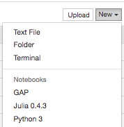

[figure not shown]

# My first notebook

- Give your notebook a name (`variables`)

[figure not shown]

[figure not shown]

# Cell types

- `Jupyter` documents are comprised of *cells*
- A `Jupyter` cell can have one of several types

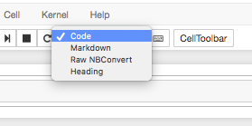

- Change the first cell to `Markdown`

# Markdown text

- `Markdown` allows us to enter formatted text.

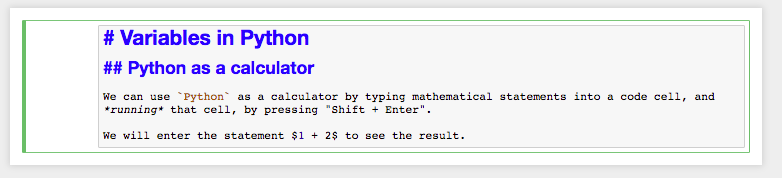

- Execute a cell with `Shift + Enter`

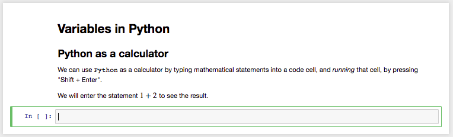

# Entering code

- Mathematical statements can be entered directly into a code cell

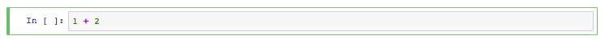

- Execute a cell with `Shift + Enter`

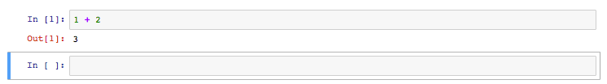

# Exercise (5min)

- Try out some of your own calculations in code cells, e.g.

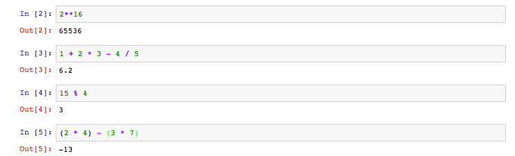

# My first variable

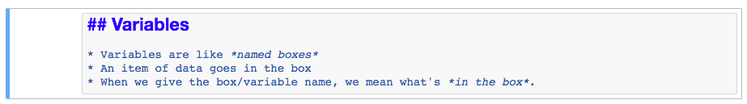

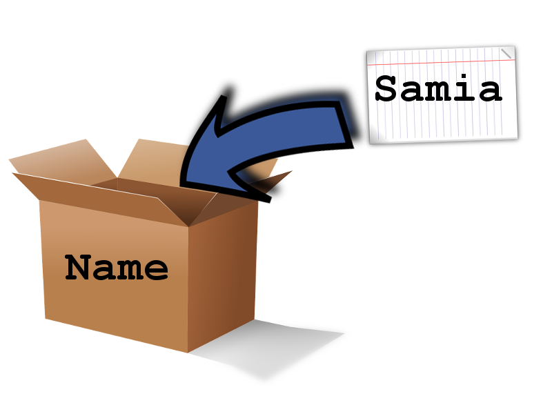

- Let’s create a variable called `name`, containing `"Samia"`

# Printing a variable

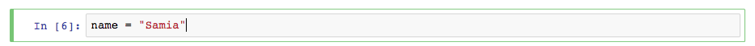

- The `print()` *function* shows the contents of a variable

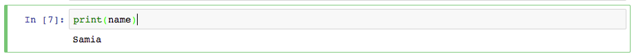

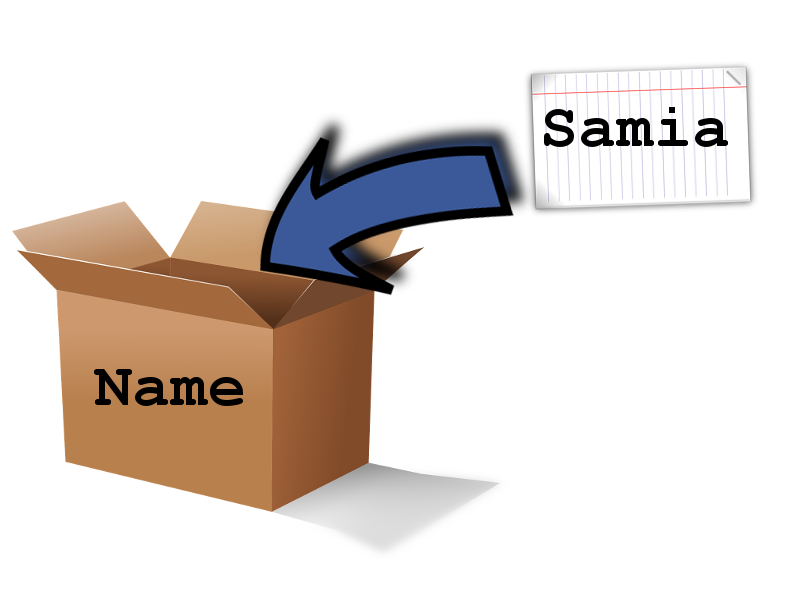

# Working with variables

- **LIVE DEMO**

```python
weight_kg = 55
print(weight_kg)
2.2 * weight_kg
print("weight in pounds", 2.2 * weight_kg)
weight_kg = 57.5
print("weight in kilograms is now:", weight_kg)
weight_lb = 2.2 * weight_kg
print('weight in kilograms:', weight_kg, 'and in pounds:', weight_lb)
weight_kg = 100
print('weight in kilograms:', weight_kg, 'and in pounds:', weight_lb)
```

# Who’s who in memory?

- **If you are in a `Jupyter` notebook or `iPython` terminal…**
- `%whos` will show you all defined variables

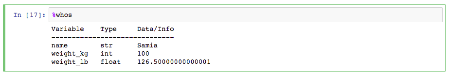